# Monte Carlo Integration: Session Exercises

Module 1, Day 1 — DATASCI 406, Computational Methods in Statistics and Data Science

Mark M. Fredrickson (mfredric@umich.edu)

Exercise 1 builds your toolbox of samplers. Every exercise after it uses the recipe from the video:

1. Write the integral as $\text{E}\left(h(X)\right)$ for a random variable $X$ you can sample.
2. Sample $X_1, \ldots, X_n$ and average $h(X_i)$.
3. Report a confidence interval, not just the point estimate.

Each integration exercise has a known true value, so you can check your work. Your estimates will differ from the targets — that is the point. Your confidence interval should usually cover the target.

# 1. A tour of R’s distributions

Let’s investigate the distributions available in R. `?Distributions` lists every distribution R ships with; each has the `r`/`d`/`p`/`q` functions from the video.

## Exercise

**(a)** Here is a start on a catalog of draws, in the long format that `ggplot` likes:

```r
n <- 1000
draws <- list(
  norm   = rnorm(n),
  unif   = runif(n),
  exp    = rexp(n),
  cauchy = rcauchy(n)
) |> enframe() |> unnest(value)

draws |> group_by(name) |> summarize(mean(value))
```

```
#> # A tibble: 4 × 2
#>   name   `mean(value)`
#>   <chr>          <dbl>
#> 1 cauchy      -5.75
#> 2 exp          1.02
#> 3 norm         0.00762
#> 4 unif         0.504
```

Extend the list with **at least six more** distributions from the `?Distributions` page, mixing continuous and discrete. Most need parameters — check the help page (e.g. `?rgamma`) and pick any sensible values; skip `rmultinom` (it returns a matrix). Then plot the whole catalog as histograms in one faceted figure (`facet_wrap(~ name, scales = "free")`).

The **Cauchy** panel will look broken — one bar and a huge empty axis. It is not a bug. Investigate:

- Re-run your `summarize()` of the sample means a few times. Every other distribution’s mean barely moves between runs. What does the Cauchy’s do?
- Look at `sort(abs(rcauchy(n)), decreasing = TRUE)[1:5]` a few times. Where is the histogram’s x-axis coming from?

**(b)** Pick **two** distributions from your catalog and explore their parameters, plotting draws across a grid of parameter values. Here is the pattern, applied to the Normal — `expand_grid()` builds every combination, and `map2()` draws a sample for each row:

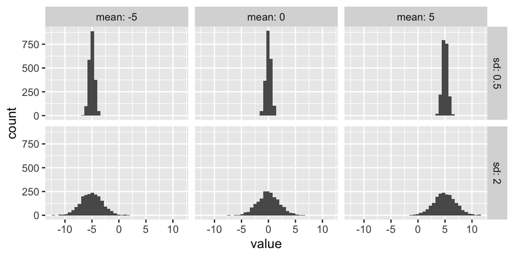

```r
expand_grid(mean = c(-5, 0, 5), sd = c(0.5, 2)) |>
  mutate(value = map2(mean, sd, ~ rnorm(2000, mean = .x, sd = .y))) |>
  unnest(value) |>
  ggplot(aes(x = value)) +
  geom_histogram(bins = 40) +
  facet_grid(sd ~ mean, labeller = label_both)
```

Adapt it to two distributions of your choice (not the Normal). For at least one of them, find parameter settings that make it match a distribution you already know.

# 2. An integral on [0, 1]

For an integral over $[0,1]$, $\int_0^1 g(x)\,dx = \text{E}\left(g(U)\right)$, where $U$ is uniform on $[0, 1]$. We can estimate the value of this integral by taking a sample of IID uniform draws and computing the sample mean of $g(U_i)$.

## Exercise

Estimate
$$\theta = \int_0^1 \sin(\pi x)
\, dx$$
using 10,000 uniform draws. Give a 95% confidence interval using `t.test`.

The true value is $2/\pi \approx 0.6366$. Does your interval cover it?

# 3. Same integral, two RVs

The general recipe works with **any** density $f$ that is positive on the domain: $\int g(x)\,dx = \text{E}\left(g(X)/f(X)\right)$ for $X \sim f$. Different choices of $f$ give different estimators of the **same** integral. Are they equally good?

## Exercise

Estimate
$$\theta = \int_0^\infty x^2
e^{-x} \, dx$$
(true value $\Gamma(3) = 2! = 2$) twice, with 10,000 draws each:

**(a)** with $f = $ Exp(1) draws (`rexp` / `dexp`), and

**(b)** with $f = $ Gamma(shape 2, rate 1) draws (`rgamma` / `dgamma`) — the Gamma family from exercise 1.

Before coding, simplify $h(x) = g(x)/f(x)$ by hand in each case — both simplify pleasantly.

**(c)** Report a 95% confidence interval for each. Both estimate the same $\theta$ from the same number of draws — which interval is narrower, and by roughly what factor?

**(d)** Plot the **ECDFs** of the 10,000 $h$ values from (a) and the 10,000 from (b) on one set of axes (`stat_ecdf()`). What do the two curves have in common, and how does their difference explain (c)?

**(e)** Repeat with $f = $ Gamma(shape 3, rate 1). Something strange happens — run it, then explain.

# 4. Probabilities are expectations of indicators

Recall an indicator function is a function that has the value 1 if a statement is true and 0 if the statement is false. They are the mathematical equivalent of `if` statements and conditionals in R. An important result is that for event $A$,

$$P(A) = E(\mathbf{1}(A))$$

In other words, we can estimate probabilities in the same way we estimate expectations.

## Exercise

For $Z \sim N(0, 1)$, estimate
$$\theta = P(1 \le Z \le 2)$$
using 100,000 draws.

1. Write the indicator directly in R (no `ifelse` needed).
2. Give a 99% confidence interval. Which is the right tool here, `t.test` or `binom.test`, and why?
3. Check against the exact value from `pnorm`.

# 5. Joint distributions

Nothing in the recipe is one-dimensional. A double integral is an expectation over a random **pair**: sample both coordinates, apply $h$, average. When the coordinates are independent, sampling the pair is just two calls to an `r` function.

## Exercise

**(a)** For $X, Y$ independent $U(0, 1)$, estimate the double integral
$$\theta = \int_0^1 \int_0^1
|x - y| \, dx \, dy = \text{E}\left(|X - Y|\right)$$
with 100,000 pairs and a 95% confidence interval. The true value is $1/3$.

**(b)** For $Z_1, Z_2$ independent $N(0, 1)$, estimate
$$P(Z_1 < Z_2 + 1)$$
with a 99% confidence interval, using the right interval tool for the job. Then check it exactly: what is the distribution of $Z_1 - Z_2$?

# 6. When the recipe breaks

The video stated conditions: $\text{E}\left(h(X)\right) < \infty$ **and** $\text{E}\left(h(X)^2\right) < \infty$. This exercise is about what happens when the second one fails.

## Exercise

Estimate
$$\theta = \int_0^\infty
\frac{1}{1 + x^2} \, dx$$
using Exp(1) draws, so $h(x) = e^{x} / (1 + x^2)$. The true value is $\pi/2 \approx 1.5708$.

1. Run the estimator with $n = 100{,}000$ **five separate times** (`replicate` helps). Do the answers agree with each other? With the truth?
2. The estimator is unbiased — we proved that in the video. So what is going wrong? Look at $\text{E}\left(h(X)^2\right)$.
3. Would increasing $n$ fix this?